# Notebook

## 03b_Model_Selection_pax_fare

New notebook

## Model Training & Selection

Target variable: Passenger Fare Prediction

```python
# Libraries
import pandas as pd
import numpy as np
import matplotlib.pyplot as plt
import seaborn as sns
from pyspark.sql import SparkSession
from pyspark.sql.functions import to_date

# Set float display to avoid scientific notation
pd.set_option('display.float_format', '{:.2f}'.format)

# Wranings
import warnings
warnings.filterwarnings('ignore')
```

```
StatementMeta(, 4ec74a9f-e500-4bbd-ae15-56e3903632d8, 3, Finished, Available, Finished)
```

### Read Data

```python
# Read data
train_df = pd.read_parquet("/lakehouse/default/Files/engineered/train_df6_base_pax_fare.parquet")
train_df.head()
```

```
StatementMeta(, 4ec74a9f-e500-4bbd-ae15-56e3903632d8, 4, Finished, Available, Finished)
```

|  | trip_miles | trip_time | base_passenger_fare | tolls | bcf | sales_tax | congestion_surcharge | airport_fee | tips | driver_pay | ... | pickup_dayofmonth_26 | pickup_dayofmonth_27 | pickup_dayofmonth_28 | pickup_dayofmonth_29 | pickup_dayofmonth_30 | time_of_day_Evening | time_of_day_Morning | time_of_day_Night | is_high_tip_1 | is_night_ride_1 |
| --- | --- | --- | --- | --- | --- | --- | --- | --- | --- | --- | --- | --- | --- | --- | --- | --- | --- | --- | --- | --- | --- |
| 0 | 1.36 | 0.82 | 3.66 | -0.36 | 0.67 | 0.83 | -0.74 | -0.31 | -0.45 | 0.95 | ... | 0 | 0 | 0 | 0 | 0 | 0 | 0 | 0 | 0 | 0 |
| 1 | 1.10 | 1.36 | 2.61 | -0.36 | -0.71 | -0.63 | -0.74 | -0.31 | -0.45 | 0.59 | ... | 0 | 0 | 0 | 0 | 0 | 1 | 0 | 0 | 0 | 0 |
| 2 | -1.06 | -1.31 | 2.38 | -0.36 | -0.93 | -0.88 | -0.74 | -0.31 | -0.45 | -1.44 | ... | 0 | 0 | 0 | 0 | 0 | 0 | 1 | 0 | 0 | 0 |
| 3 | 0.55 | 0.20 | 3.51 | -0.36 | 0.35 | 0.60 | 1.36 | -0.31 | 1.68 | 0.21 | ... | 0 | 0 | 0 | 0 | 0 | 0 | 0 | 1 | 0 | 1 |
| 4 | -0.12 | 0.50 | 2.75 | -0.36 | -0.60 | -0.46 | -0.74 | -0.31 | -0.45 | -0.00 | ... | 0 | 0 | 0 | 0 | 0 | 1 | 0 | 0 | 0 | 0 |

5 rows × 82 columns

```python
# Shape
train_df.shape
```

```
StatementMeta(, 4ec74a9f-e500-4bbd-ae15-56e3903632d8, 5, Finished, Available, Finished)
```

```
(2000000, 82)
```

```python
# Info
train_df.info()
```

```
StatementMeta(, 4ec74a9f-e500-4bbd-ae15-56e3903632d8, 6, Finished, Available, Finished)
```

```
<class 'pandas.core.frame.DataFrame'>
RangeIndex: 2000000 entries, 0 to 1999999
Data columns (total 82 columns):
 #   Column                    Dtype
---  ------                    -----
 0   trip_miles                float64
 1   trip_time                 float64
 2   base_passenger_fare       float64
 3   tolls                     float64
 4   bcf                       float64
 5   sales_tax                 float64
 6   congestion_surcharge      float64
 7   airport_fee               float64
 8   tips                      float64
 9   driver_pay                float64
```

[output cut: 74 more lines]

### Correlations

```python
# describe Continuous features
train_df.select_dtypes('float64').describe()
```

```
StatementMeta(, 4ec74a9f-e500-4bbd-ae15-56e3903632d8, 7, Finished, Available, Finished)
```

|  | trip_miles | trip_time | base_passenger_fare | tolls | bcf | sales_tax | congestion_surcharge | airport_fee | tips | driver_pay | cbd_congestion_fee | driver_pay_per_mile |
| --- | --- | --- | --- | --- | --- | --- | --- | --- | --- | --- | --- | --- |
| count | 2000000.00 | 2000000.00 | 2000000.00 | 2000000.00 | 2000000.00 | 2000000.00 | 2000000.00 | 2000000.00 | 2000000.00 | 2000000.00 | 2000000.00 | 2000000.00 |
| mean | 0.00 | 0.00 | 3.12 | -0.00 | 0.00 | -0.00 | -0.00 | -0.00 | 0.00 | 0.00 | -0.00 | -0.00 |
| std | 1.00 | 1.00 | 0.65 | 1.00 | 1.00 | 1.00 | 1.00 | 1.00 | 1.00 | 1.00 | 1.00 | 1.00 |
| min | -1.59 | -2.36 | 1.97 | -0.36 | -1.25 | -2.15 | -0.74 | -0.31 | -0.45 | -1.85 | -0.71 | -1.70 |
| 25% | -0.81 | -0.70 | 2.62 | -0.36 | -0.73 | -0.70 | -0.74 | -0.31 | -0.45 | -0.76 | -0.71 | -0.70 |
| 50% | -0.17 | 0.02 | 3.04 | -0.36 | -0.28 | -0.15 | -0.74 | -0.31 | -0.45 | -0.04 | -0.71 | -0.11 |
| 75% | 0.69 | 0.71 | 3.54 | -0.36 | 0.47 | 0.59 | 1.36 | -0.31 | -0.45 | 0.70 | 1.40 | 0.51 |
| max | 2.60 | 2.25 | 4.87 | 3.73 | 3.49 | 2.81 | 1.36 | 3.19 | 3.51 | 2.44 | 1.40 | 3.38 |

```python
# Set continuous features
continuous_features = train_df.select_dtypes('float64').columns
```

```
StatementMeta(, 4ec74a9f-e500-4bbd-ae15-56e3903632d8, 8, Finished, Available, Finished)
```

```
StatementMeta(, 4ec74a9f-e500-4bbd-ae15-56e3903632d8, 9, Finished, Available, Finished)
```

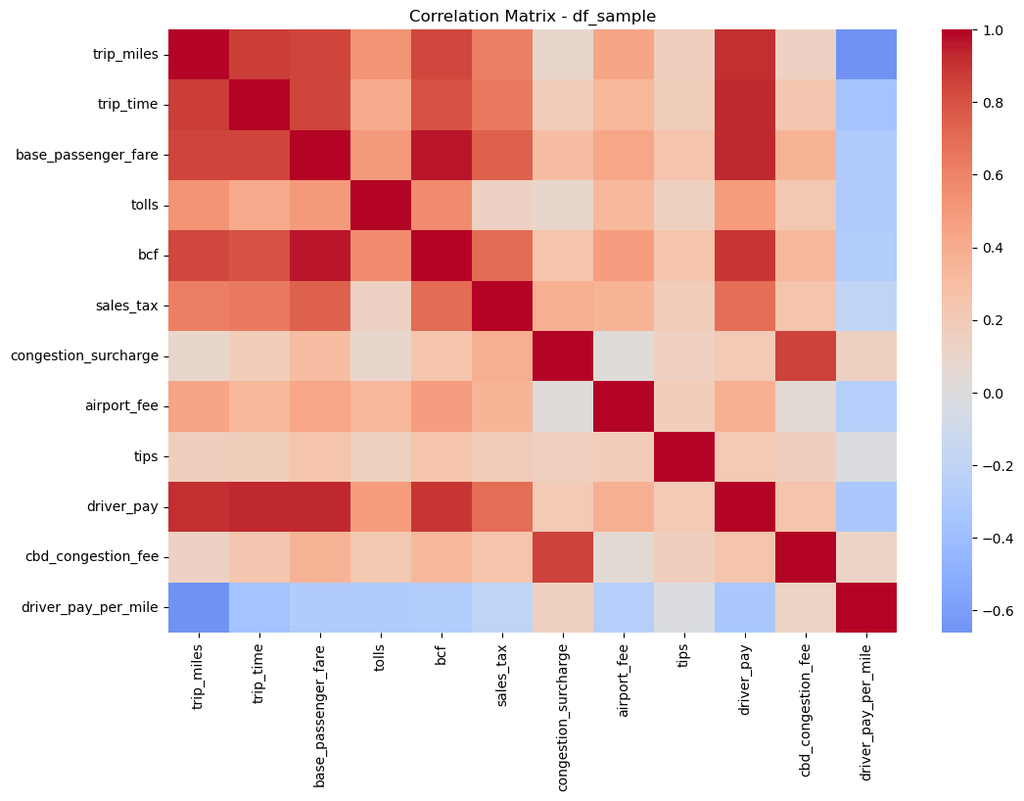

```
                      trip_miles  trip_time  base_passenger_fare  tolls   bcf  \
trip_miles                  1.00       0.86                 0.85   0.53  0.83
trip_time                   0.86       1.00                 0.85   0.42  0.80
base_passenger_fare         0.85       0.85                 1.00   0.50  0.96
tolls                       0.53       0.42                 0.50   1.00  0.56
bcf                         0.83       0.80                 0.96   0.56  1.00
sales_tax                   0.62       0.65                 0.74   0.14  0.70
congestion_surcharge        0.09       0.19                 0.31   0.09  0.26
airport_fee                 0.44       0.33                 0.43   0.33  0.48
tips                        0.17       0.17                 0.25   0.15  0.26
driver_pay                  0.91       0.93                 0.93   0.48  0.89
cbd_congestion_fee          0.14       0.24                 0.36   0.23  0.33
driver_pay_per_mile        -0.66      -0.36                -0.29  -0.29 -0.28

                      sales_tax  congestion_surcharge  airport_fee  tips  \
trip_miles                 0.62                  0.09         0.44  0.17
trip_time                  0.65                  0.19         0.33  0.17
base_passenger_fare        0.74                  0.31         0.43  0.25
tolls                      0.14                  0.09         0.33  0.15
bcf                        0.70                  0.26         0.48  0.26
sales_tax                  1.00                  0.39         0.36  0.19
congestion_surcharge       0.39                  1.00         0.02  0.16
airport_fee                0.36                  0.02         1.00  0.19
tips                       0.19                  0.16         0.19  1.00
driver_pay                 0.69                  0.20         0.39  0.20
cbd_congestion_fee         0.26                  0.86         0.05  0.17
driver_pay_per_mile       -0.19                  0.15        -0.26 -0.01

                      driver_pay  cbd_congestion_fee  driver_pay_per_mile
trip_miles                  0.91                0.14                -0.66
trip_time                   0.93                0.24                -0.36
base_passenger_fare         0.93                0.36                -0.29
tolls                       0.48                0.23                -0.29
bcf                         0.89                0.33                -0.28
sales_tax                   0.69                0.26                -0.19
congestion_surcharge        0.20                0.86                 0.15
airport_fee                 0.39                0.05                -0.26
tips                        0.20                0.17                -0.01
driver_pay                  1.00                0.26                -0.32
cbd_congestion_fee          0.26                1.00                 0.13
driver_pay_per_mile        -0.32                0.13                 1.00
```

```python
# calculate correlations only for numeric columns (continous only, not categorical)
corr_matrix = train_df.select_dtypes(include='float64').corr(numeric_only=True)

# heatmap
plt.figure(figsize=(12, 8))
sns.heatmap(corr_matrix, annot=False, cmap="coolwarm", center=0)
plt.title("Correlation Matrix - df_sample")
plt.show()

# if you want to check only correlation with the target
print(corr_matrix)
```

### Selecting Features (X), Target (y)

```python
# Shape
train_df.shape
```

```
StatementMeta(, 4ec74a9f-e500-4bbd-ae15-56e3903632d8, 10, Finished, Available, Finished)
```

```
(2000000, 82)
```

```python
# Sample 100K rows
sample_train_df = train_df.sample(n=100_000, random_state=42)  # random_state for reproducibility
```

```
StatementMeta(, 4ec74a9f-e500-4bbd-ae15-56e3903632d8, 11, Finished, Available, Finished)
```

```python
# Columns
train_df.columns
```

```
StatementMeta(, 4ec74a9f-e500-4bbd-ae15-56e3903632d8, 12, Finished, Available, Finished)
```

```
Index(['trip_miles', 'trip_time', 'base_passenger_fare', 'tolls', 'bcf',
       'sales_tax', 'congestion_surcharge', 'airport_fee', 'tips',
       'driver_pay', 'cbd_congestion_fee', 'driver_pay_per_mile',
       'hvfhs_license_num_HV0005', 'shared_request_flag_1',
       'shared_match_flag_1', 'access_a_ride_flag_1', 'wav_request_flag_1',
       'wav_match_flag_1', 'pickup_hour_1', 'pickup_hour_2', 'pickup_hour_3',
       'pickup_hour_4', 'pickup_hour_5', 'pickup_hour_6', 'pickup_hour_7',
       'pickup_hour_8', 'pickup_hour_9', 'pickup_hour_10', 'pickup_hour_11',
       'pickup_hour_12', 'pickup_hour_13', 'pickup_hour_14', 'pickup_hour_15',
       'pickup_hour_16', 'pickup_hour_17', 'pickup_hour_18', 'pickup_hour_19',
       'pickup_hour_20', 'pickup_hour_21', 'pickup_hour_22', 'pickup_hour_23',
       'pickup_dayofweek_1', 'pickup_dayofweek_2', 'pickup_dayofweek_3',
       'pickup_dayofweek_4', 'pickup_dayofweek_5', 'pickup_dayofweek_6',
       'is_weekend_1', 'pickup_dayofmonth_2', 'pickup_dayofmonth_3',
       'pickup_dayofmonth_4', 'pickup_dayofmonth_5', 'pickup_dayofmonth_6',
       'pickup_dayofmonth_7', 'pickup_dayofmonth_8', 'pickup_dayofmonth_9',
       'pickup_dayofmonth_10', 'pickup_dayofmonth_11', 'pickup_dayofmonth_12',
       'pickup_dayofmonth_13', 'pickup_dayofmonth_14', 'pickup_dayofmonth_15',
       'pickup_dayofmonth_16', 'pickup_dayofmonth_17', 'pickup_dayofmonth_18',
       'pickup_dayofmonth_19', 'pickup_dayofmonth_20', 'pickup_dayofmonth_21',
       'pickup_dayofmonth_22', 'pickup_dayofmonth_23', 'pickup_dayofmonth_24',
       'pickup_dayofmonth_25', 'pickup_dayofmonth_26', 'pickup_dayofmonth_27',
       'pickup_dayofmonth_28', 'pickup_dayofmonth_29', 'pickup_dayofmonth_30',
       'time_of_day_Evening', 'time_of_day_Morning', 'time_of_day_Night',
       'is_high_tip_1', 'is_night_ride_1'],
      dtype='object')
```

```python
# Target
y = sample_train_df['base_passenger_fare']

# Features (changes per modelling demands)
X = sample_train_df.drop(columns=['base_passenger_fare', 'bcf', 'driver_pay', 'sales_tax',
        'driver_pay_per_mile', 'tips', 'is_high_tip_1'])
```

```
StatementMeta(, 4ec74a9f-e500-4bbd-ae15-56e3903632d8, 13, Finished, Available, Finished)
```

**Note**: bcf and driver pay have high correlation with base passenger fares, appears to be derived from base fares, therefore eliminated from training data

```python
# Shape
print ("Shape of X" , X.shape)
print ("Shape of y" , y.shape)
```

```
StatementMeta(, 4ec74a9f-e500-4bbd-ae15-56e3903632d8, 14, Finished, Available, Finished)
```

```
Shape of X (100000, 75)
Shape of y (100000,)
```

### Train Test Split

```python
# Train - test split
from sklearn.model_selection import train_test_split

X_train, X_test, y_train, y_test = train_test_split(
    X, y, test_size=0.2, random_state=42)
```

```
StatementMeta(, 4ec74a9f-e500-4bbd-ae15-56e3903632d8, 15, Finished, Available, Finished)
```

```python
# Shapes
print ("Shape of X_train:" , X_train.shape)
print ("Shape of y_train:" , y_train.shape)
print ("Shape of X_test:" , X_test.shape)
print ("Shape of y_test:" , y_test.shape)
```

```
StatementMeta(, 4ec74a9f-e500-4bbd-ae15-56e3903632d8, 16, Finished, Available, Finished)
```

```
Shape of X_train: (80000, 75)
Shape of y_train: (80000,)
Shape of X_test: (20000, 75)
Shape of y_test: (20000,)
```

```python
y_train
```

```
StatementMeta(, 4ec74a9f-e500-4bbd-ae15-56e3903632d8, 17, Finished, Available, Finished)
```

```
964430    2.09
1209451   3.09
464732    3.35
994421    2.41
1522745   3.50
          ...
662616    2.61
1134897   2.94
915663    2.96
1155215   3.23
383246    3.07
Name: base_passenger_fare, Length: 80000, dtype: float64
```

### LightGBM Model

```python
# LightGBM for Passenger Fare Prediction
from lightgbm import LGBMRegressor
import lightgbm as lgb
from sklearn.metrics import mean_squared_error, mean_absolute_error, r2_score
```

```
StatementMeta(, ca2b89db-423a-4ca7-8fff-dee25e667408, 20, Finished, Available, Finished)
```

```python
# --- Define model ---
lgb_model = LGBMRegressor(
    n_estimators=1000,
    learning_rate=0.05,
    num_leaves=31,
    subsample=0.8,
    colsample_bytree=0.8,
    random_state=42,
    objective='regression'
)
```

```
StatementMeta(, ca2b89db-423a-4ca7-8fff-dee25e667408, 21, Finished, Available, Finished)
```

```python
# Fitting and training model
lgb_model.fit(
    X_train, y_train,
    eval_set=[(X_test, y_test)],
    eval_metric='rmse',
    callbacks=[
        lgb.early_stopping(stopping_rounds=50),
        lgb.log_evaluation(100)
    ]
)
```

```
StatementMeta(, ca2b89db-423a-4ca7-8fff-dee25e667408, 22, Finished, Available, Finished)
```

[output not shown]

[output not shown]

```
LGBMRegressor(colsample_bytree=0.8, learning_rate=0.05, n_estimators=1000,
              objective='regression', random_state=42, subsample=0.8)
```

```python
# --- Predictions ---
y_pred = lgb_model.predict(X_test, num_iteration=lgb_model.best_iteration_)
```

```
StatementMeta(, ca2b89db-423a-4ca7-8fff-dee25e667408, 23, Finished, Available, Finished)
```

#### Accuracy

```python
# --- Evaluation ---
rmse = np.sqrt(mean_squared_error(y_test, y_pred))
mae = mean_absolute_error(y_test, y_pred)
r2 = r2_score(y_test, y_pred)

print(f"LightGBM Performance:")
print(f"  RMSE: {rmse:.2f}")
print(f"  MAE : {mae:.2f}")
print(f"  R²  : {r2:.4f}")
```

```
StatementMeta(, ca2b89db-423a-4ca7-8fff-dee25e667408, 24, Finished, Available, Finished)
```

```
LightGBM Performance:
  RMSE: 0.23
  MAE : 0.17
  R²  : 0.8709
```

#### Feature Importance

```
StatementMeta(, ca2b89db-423a-4ca7-8fff-dee25e667408, 25, Finished, Available, Finished)
```

```
                     feature  importance
0                 trip_miles        5223
1                  trip_time        4491
6   hvfhs_license_num_HV0005        1635
5         cbd_congestion_fee        1492
3       congestion_surcharge        1460
2                      tolls        1055
4                airport_fee         940
73         time_of_day_Night         540
74           is_night_ride_1         536
7      shared_request_flag_1         520
```

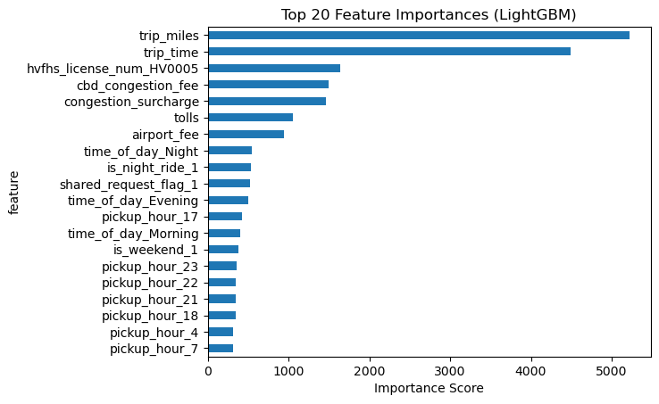

```python
# --- Get feature importance values ---
feature_importances = pd.DataFrame({
    'feature': X_train.columns,
    'importance': lgb_model.feature_importances_
})

# Sort by importance
feature_importances = feature_importances.sort_values(by='importance', ascending=False)

# --- Print Top 10 ---
print(feature_importances.head(10))

# --- Plot Top 20 ---
plt.figure(figsize=(8,6))
feature_importances.head(20).plot(
    kind='barh',
    x='feature',
    y='importance',
    legend=False
)
plt.gca().invert_yaxis()  # highest at the top
plt.title("Top 20 Feature Importances (LightGBM)")
plt.xlabel("Importance Score")
plt.show()
```

### XGBoost Model

```python
# XGBoost for Passenger Fare Prediction
from xgboost import XGBRegressor
from sklearn.metrics import mean_squared_error, mean_absolute_error, r2_score
```

```
StatementMeta(, ca2b89db-423a-4ca7-8fff-dee25e667408, 35, Finished, Available, Finished)
```

```python
# Define model
xgb_model = XGBRegressor(
    n_estimators=1000,       # number of boosting rounds
    learning_rate=0.05,      # shrinkage step
    max_depth=6,             # max tree depth
    subsample=0.8,           # row sampling
    colsample_bytree=0.8,    # column sampling
    random_state=42,
    objective='reg:squarederror',  # regression loss
    n_jobs=-1
)
```

```
StatementMeta(, ca2b89db-423a-4ca7-8fff-dee25e667408, 36, Finished, Available, Finished)
```

```python
# Train & Fit model
xgb_model.fit(
    X_train, y_train,
    eval_set=[(X_test, y_test)],  # validation set for early stopping
    eval_metric='rmse',
    early_stopping_rounds=50,
    verbose=100
)
```

```
StatementMeta(, ca2b89db-423a-4ca7-8fff-dee25e667408, 37, Finished, Available, Finished)
```

```
XGBRegressor(base_score=None, booster=None, callbacks=None,
             colsample_bylevel=None, colsample_bynode=None,
             colsample_bytree=0.8, device=None, early_stopping_rounds=None,
             enable_categorical=False, eval_metric=None, feature_types=None,
             gamma=None, grow_policy=None, importance_type=None,
             interaction_constraints=None, learning_rate=0.05, max_bin=None,
             max_cat_threshold=None, max_cat_to_onehot=None,
             max_delta_step=None, max_depth=6, max_leaves=None,
             min_child_weight=None, missing=nan, monotone_constraints=None,
             multi_strategy=None, n_estimators=1000, n_jobs=-1,
             num_parallel_tree=None, random_state=42, ...)
```

```python
# --- Predictions ---
y_pred = xgb_model.predict(X_test)
```

```
StatementMeta(, ca2b89db-423a-4ca7-8fff-dee25e667408, 38, Finished, Available, Finished)
```

#### Accuracy

```python
# --- Evaluation ---
rmse = np.sqrt(mean_squared_error(y_test, y_pred))
mae = mean_absolute_error(y_test, y_pred)
r2 = r2_score(y_test, y_pred)

print(f"XGBoost Performance:")
print(f"  RMSE: {rmse:.2f}")
print(f"  MAE : {mae:.2f}")
print(f"  R²  : {r2:.4f}")
```

```
StatementMeta(, ca2b89db-423a-4ca7-8fff-dee25e667408, 39, Finished, Available, Finished)
```

```
XGBoost Performance:
  RMSE: 0.24
  MAE : 0.17
  R²  : 0.8685
```

#### Feature Importance

```python
# --- Feature Importance ---
import pandas as pd
import matplotlib.pyplot as plt

importance = xgb_model.feature_importances_
feat_importance = pd.DataFrame({'feature': X_train.columns, 'importance': importance})
feat_importance = feat_importance.sort_values(by='importance', ascending=False)

print(feat_importance.head(10))  # Top 10 features
```

[output not shown]

```python
# Plot
plt.figure(figsize=(8,5))
feat_importance.head(20).plot(kind='barh', x='feature', y='importance', legend=False)
plt.title("Top 20 Feature Importances (XGBoost)")
plt.show()
```

[output not shown]

### CatBoost

- Identify categorical features (if any not already encoded) ---
- If you already one-hot encoded categories, leave cat_features=[].
- Otherwise, detect columns of type 'object' or 'category':
- cat_features = X_train.select_dtypes(include=['object', 'category']).columns.tolist()

```python
# Shape of train, test
print ("Shape of X_train: ", X_train.shape)
print ("Shape of y_train:", y_train.shape)
print ("Shape of X_test:", X_test.shape)
print ("Shape of y_test:", y_test.shape)
```

```
StatementMeta(, 4ec74a9f-e500-4bbd-ae15-56e3903632d8, 24, Finished, Available, Finished)
```

```
Shape of X_train:  (80000, 75)
Shape of y_train: (80000,)
Shape of X_test: (20000, 75)
Shape of y_test: (20000,)
```

```python
# Libraries
from catboost import CatBoostRegressor, Pool
from sklearn.metrics import mean_squared_error, mean_absolute_error, r2_score
```

```
StatementMeta(, 4ec74a9f-e500-4bbd-ae15-56e3903632d8, 27, Finished, Available, Finished)
```

```python
# --- Define model ---
cat_model = CatBoostRegressor(
    iterations=1000,          # number of boosting rounds
    learning_rate=0.05,
    depth=8,                  # max depth of trees
    loss_function='RMSE',
    eval_metric='RMSE',
    random_seed=42,
    od_type="Iter",           # early stopping type
    od_wait=50,               # wait 50 rounds before stopping
    verbose=100               # print every 100 iterations
)
```

```
StatementMeta(, 4ec74a9f-e500-4bbd-ae15-56e3903632d8, 22, Finished, Available, Finished)
```

```python
# Train and fit model
train_pool = Pool(X_train, y_train, cat_features=[])
test_pool = Pool(X_test, y_test, cat_features=[])

cat_model.fit(train_pool, eval_set=test_pool, use_best_model=True)
```

```
StatementMeta(, 4ec74a9f-e500-4bbd-ae15-56e3903632d8, 25, Finished, Available, Finished)
```

```
0:	learn: 0.6273977	test: 0.6269516	best: 0.6269516 (0)	total: 135ms	remaining: 2m 14s
100:	learn: 0.2458538	test: 0.2446843	best: 0.2446843 (100)	total: 921ms	remaining: 8.19s
200:	learn: 0.2400309	test: 0.2399084	best: 0.2399084 (200)	total: 1.63s	remaining: 6.49s
300:	learn: 0.2365025	test: 0.2379355	best: 0.2379355 (300)	total: 2.28s	remaining: 5.3s
400:	learn: 0.2338618	test: 0.2368209	best: 0.2368182 (398)	total: 2.94s	remaining: 4.39s
500:	learn: 0.2317778	test: 0.2362111	best: 0.2362111 (500)	total: 3.67s	remaining: 3.65s
600:	learn: 0.2299339	test: 0.2358665	best: 0.2358665 (600)	total: 4.37s	remaining: 2.9s
700:	learn: 0.2282509	test: 0.2356722	best: 0.2356618 (694)	total: 5.71s	remaining: 2.43s
800:	learn: 0.2267518	test: 0.2355491	best: 0.2355491 (800)	total: 6.73s	remaining: 1.67s
900:	learn: 0.2253171	test: 0.2354793	best: 0.2354728 (899)	total: 7.57s	remaining: 832ms
Stopped by overfitting detector  (50 iterations wait)

bestTest = 0.2354433965
bestIteration = 926

Shrink model to first 927 iterations.
```

```
<catboost.core.CatBoostRegressor at 0x72e02b8c7050>
```

#### Accuracy

```python
# Predictions
y_pred = cat_model.predict(X_test)

# --- Evaluation ---
rmse = np.sqrt(mean_squared_error(y_test, y_pred))
mae = mean_absolute_error(y_test, y_pred)
r2 = r2_score(y_test, y_pred)

print(f"CatBoost Performance:")
print(f"  RMSE: {rmse:.2f}")
print(f"  MAE : {mae:.2f}")
print(f"  R²  : {r2:.4f}")
```

```
StatementMeta(, 4ec74a9f-e500-4bbd-ae15-56e3903632d8, 28, Finished, Available, Finished)
```

```
CatBoost Performance:
  RMSE: 0.24
  MAE : 0.17
  R²  : 0.8697
```

#### Feature Importance

```python
# --- Feature Importance ---
feature_importances = cat_model.get_feature_importance(prettified=True)
print(feature_importances.head(10))  # Top 10 features
```

[output not shown]

### Neural Nets

#### Simple Neural Net - PyTorch for Fare Prediction

```python
# Libraries
import torch
import torch.nn as nn
import torch.optim as optim
from sklearn.metrics import mean_squared_error, mean_absolute_error, r2_score
import numpy as np
```

```
StatementMeta(, 4ec74a9f-e500-4bbd-ae15-56e3903632d8, 30, Finished, Available, Finished)
```

```python
# Convert data to torch tensors
X_train_t = torch.tensor(X_train.values, dtype=torch.float32)
y_train_t = torch.tensor(y_train.values, dtype=torch.float32).view(-1, 1)
X_test_t  = torch.tensor(X_test.values, dtype=torch.float32)
y_test_t  = torch.tensor(y_test.values, dtype=torch.float32).view(-1, 1)
```

```
StatementMeta(, 4ec74a9f-e500-4bbd-ae15-56e3903632d8, 31, Finished, Available, Finished)
```

```python
# Define simple MLP model
class FareNN(nn.Module):
    def __init__(self, input_dim):
        super(FareNN, self).__init__()
        self.layers = nn.Sequential(
            nn.Linear(input_dim, 64),
            nn.ReLU(),
            nn.Dropout(0.2),
            nn.Linear(64, 32),
            nn.ReLU(),
            nn.Linear(32, 1)
        )
    def forward(self, x):
        return self.layers(x)
```

```
StatementMeta(, 4ec74a9f-e500-4bbd-ae15-56e3903632d8, 32, Finished, Available, Finished)
```

```python
# Initialize model
model = FareNN(X_train.shape[1])
criterion = nn.MSELoss()
optimizer = optim.Adam(model.parameters(), lr=0.001)
```

```
StatementMeta(, 4ec74a9f-e500-4bbd-ae15-56e3903632d8, 33, Finished, Available, Finished)
```

```python
# Training loop
epochs = 50
batch_size = 128

for epoch in range(epochs):
    model.train()
    perm = torch.randperm(X_train_t.size(0))
    for i in range(0, X_train_t.size(0), batch_size):
        idx = perm[i:i+batch_size]
        batch_x, batch_y = X_train_t[idx], y_train_t[idx]

        optimizer.zero_grad()
        outputs = model(batch_x)
        loss = criterion(outputs, batch_y)
        loss.backward()
        optimizer.step()

    # Validation RMSE every 10 epochs
    if (epoch+1) % 10 == 0:
        model.eval()
        with torch.no_grad():
            val_preds = model(X_test_t).numpy()
            rmse = np.sqrt(mean_squared_error(y_test, val_preds))
            print(f"Epoch {epoch+1}/{epochs}, Val RMSE: {rmse:.4f}")
```

[output not shown]

```
StatementMeta(, 4ec74a9f-e500-4bbd-ae15-56e3903632d8, 34, Finished, Available, Finished)
```